# Data Analyst Assignment

> *Noon Academy*

#### Contents:

1. Data Preprocessing
2. Exploratory Data Analysis
3. Problem 1: Cohort Analysis
4. Problem 2: Retention Analysis
5. Clustering Analysis

```python
#importing required packages
import pandas as pd
import numpy as np
import matplotlib.pyplot as plt
import seaborn as sns
from scipy import stats
import copy
sns.set(color_codes=True)

%matplotlib inline
plt.rcParams['figure.figsize'] = [10, 5]
```

```python
#Reading the dataset
xls = pd.ExcelFile('Data Analyst-assignment.xlsx')
activities = pd.read_excel(xls, 'Activity Log (Sep 1 - Oct 13)')
students = pd.read_excel(xls, 'Students')
teachers = pd.read_excel(xls, 'Teachers')
```

### 1. Data Preprocessing

##### Checking top rows of dataset and variable type

```python
activities.head()
```

|  | students | activity_type | date | group_id | teacher_id |
| --- | --- | --- | --- | --- | --- |
| 0 | 2679779 | attend_session | 2019-10-05 | 953 | 240904 |
| 1 | 1502728 | attend_session | 2019-09-16 | 1287 | 364849 |
| 2 | 2676850 | attend_session | 2019-10-03 | 2520 | 364849 |
| 3 | 2676850 | attend_session | 2019-10-03 | 2520 | 364849 |
| 4 | 2679779 | attend_session | 2019-10-05 | 2520 | 364849 |

```python
activities.info()
```

```
<class 'pandas.core.frame.DataFrame'>
RangeIndex: 16707 entries, 0 to 16706
Data columns (total 5 columns):
students         16707 non-null int64
activity_type    16707 non-null object
date             16707 non-null datetime64[ns]
group_id         16707 non-null int64
teacher_id       16707 non-null int64
dtypes: datetime64[ns](1), int64(3), object(1)
memory usage: 652.7+ KB
```

```python
students.head()
```

|  | student | school_id | grade | signup_date |
| --- | --- | --- | --- | --- |
| 0 | 114565 | 19231 | 11.0 | 2014-12-12 |
| 1 | 329492 | 41980 | NaN | 2015-11-16 |
| 2 | 478295 | 19231 | 12.0 | 2016-06-30 |
| 3 | 493803 | 41980 | 12.0 | 2016-08-21 |
| 4 | 560168 | 19231 | 10.0 | 2016-10-23 |

```python
students.info()
```

```
<class 'pandas.core.frame.DataFrame'>
RangeIndex: 432 entries, 0 to 431
Data columns (total 4 columns):
student        432 non-null int64
school_id      432 non-null int64
grade          423 non-null float64
signup_date    432 non-null datetime64[ns]
dtypes: datetime64[ns](1), float64(1), int64(2)
memory usage: 13.6 KB
```

```python
teachers.head()
```

|  | teacher_id | school_id |
| --- | --- | --- |
| 0 | 240904 | 42614.0 |
| 1 | 329492 | 41980.0 |
| 2 | 436016 | NaN |
| 3 | 885779 | NaN |
| 4 | 886982 | 23218.0 |

```python
teachers.info()
```

```
<class 'pandas.core.frame.DataFrame'>
RangeIndex: 186 entries, 0 to 185
Data columns (total 2 columns):
teacher_id    186 non-null int64
school_id     86 non-null float64
dtypes: float64(1), int64(1)
memory usage: 3.0 KB
```

```python
#Column 'student' and 'students' mean the same for Student and Activities tables. Changing them to be same
students.rename(columns = {'student':'students'}, inplace = True)
```

```python
students.columns
```

```
Index(['students', 'school_id', 'grade', 'signup_date'], dtype='object')
```

```python
len(students['students'].unique())
```

```
432
```

```python
len(teachers['teacher_id'].unique())
```

```
186
```

teacher_id and students are the primary keys for tables teachers and students

##### Checking the number of nulls

```python
print(len(activities))
activities.isnull().sum()
```

```
16707
```

```
students         0
activity_type    0
date             0
group_id         0
teacher_id       0
dtype: int64
```

```python
print(len(students))
students.isnull().sum()
```

```
432
```

```
students       0
school_id      0
grade          9
signup_date    0
dtype: int64
```

```python
print(len(teachers))
teachers.isnull().sum()
```

```
186
```

```
teacher_id      0
school_id     100
dtype: int64
```

There are no nulls in activities dataset.  
There are 9 nulls in students dataset (grade column) out of 432 rows. It can be treated with ease.  
For teachers dataset, there are 100 nulls in 186 rows. They cannot be cleaned. We'll replace these values by No School.

##### Treating missing values

```python
#Replacing school_id of teachers with no school as 'No_School'
teachers.fillna('No_School', inplace = True)
```

```python
#Treating grade column in students table by checking group of these students from activities table and
#then replacing missing grades with grade of students in that group

#List of students with missing grades
missing_stu = pd.DataFrame(students.loc[students['grade'].isnull(),'students'])

#Adding group_id of missing students
group_req = missing_stu.merge(activities[['students','group_id']].drop_duplicates(), left_on='students',right_on='students', how = 'left')
#Getting the most common group
group_req = pd.DataFrame(group_req.groupby(['students'])['group_id'].agg(lambda x: stats.mode(x)[0]))

#Getting student_id of all students from the shortlisted groups
students_from_group = group_req[['group_id']].merge(activities[['students','group_id']].drop_duplicates(), left_on='group_id',right_on='group_id', how = 'left')

#Getting grade of students shortlisted in last step
students_group_grade = students_from_group.merge(students[['students','grade']], left_on='students', right_on='students', how = 'left')

#Adding grade back to the list of missing students using group_id
missing_grades = students_group_grade[['group_id','grade']].dropna().drop_duplicates().merge(group_req, left_on = 'group_id', right_on = 'group_id', how='inner')

#Selecting grades and student
missing_grades[['students','grade']].drop_duplicates().reset_index().sort_values(by='students')
```

|  | index | students | grade |
| --- | --- | --- | --- |
| 0 | 0 | 329492 | 12.0 |
| 1 | 1 | 329492 | 10.0 |
| 2 | 2 | 1696326 | 12.0 |
| 4 | 4 | 1696326 | 10.0 |
| 6 | 10 | 1696326 | 11.0 |
| 7 | 12 | 1696326 | 8.0 |
| 3 | 3 | 2085500 | 12.0 |
| 5 | 5 | 2085500 | 10.0 |
| 8 | 15 | 2141903 | 11.0 |
| 9 | 16 | 2605387 | 11.0 |
| 10 | 17 | 2605387 | 12.0 |
| 11 | 18 | 2605387 | 10.0 |
| 12 | 19 | 2605391 | 11.0 |
| 13 | 20 | 2609000 | 10.0 |
| 14 | 21 | 2609000 | 11.0 |
| 15 | 24 | 2609000 | 8.0 |
| 16 | 25 | 2609000 | 12.0 |
| 17 | 40 | 2611257 | 11.0 |

There are multiple grades associated with a single group, causing the output to have multiple grades for one student.  
To avoid this situation, we should create a table with group and mode of grade and use that to substitute missing values of grades.

```python
#creating group-grade table as: For every group we get the mode of grade
group_grade = pd.DataFrame(activities[['group_id','students']].drop_duplicates().merge(students[['students','grade']],
            on = 'students')[['grade','group_id']].drop_duplicates().dropna().groupby(['group_id'])['grade'].agg(lambda x: stats.mode(x)[0]))
group_grade.head()
```

| group_id | grade |
| --- | --- |
| 13 | 11.0 |
| 23 | 10.0 |
| 40 | 10.0 |
| 49 | 7.0 |
| 59 | 11.0 |

```python
#merging group_grade table with group student table to get grades of missing students
student_grade = group_req.merge(group_grade, left_on = 'group_id', right_index = True).reset_index()[['students', 'grade']]. drop_duplicates()
students_new = students.merge(student_grade,on='students',how='left')

#Replacing na's with new values of grade
students_new['grade_x'].fillna(students_new['grade_y'], inplace = True)
students = students_new.iloc[:,0:4]

#Renaming column name
students.rename(columns = {'grade_x':'grade'}, inplace= True)
students.head()
```

|  | students | school_id | grade | signup_date |
| --- | --- | --- | --- | --- |
| 0 | 114565 | 19231 | 11.0 | 2014-12-12 |
| 1 | 329492 | 41980 | 12.0 | 2015-11-16 |
| 2 | 478295 | 19231 | 12.0 | 2016-06-30 |
| 3 | 493803 | 41980 | 12.0 | 2016-08-21 |
| 4 | 560168 | 19231 | 10.0 | 2016-10-23 |

##### Outlier Detection

There is no column for outlier detection in current state. Hence skipping it for now.  
Maybe need to perform later when we transform the data.

### 2. Exploratory data analysis

##### Univariate analysis

- Activities table

```python
act_dist = activities.groupby('activity_type')['students'].count().reset_index()

act_dist['Percentage'] = 100 * act_dist['students']  / act_dist['students'].sum()

print(act_dist)
```

```
    activity_type  students  Percentage
0  attend_session     12104   72.448674
1         comment      1595    9.546897
2        homework      1810   10.833782
3      join_group       934    5.590471
4            post       264    1.580176
```

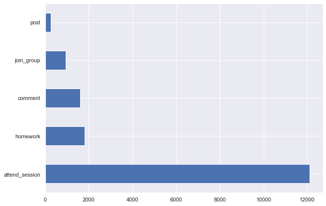

```python
activities['activity_type'].value_counts().plot(kind='barh')
```

**Finding:** Only ~16% of all activities are student engagement activities (comment, post, join_group).

```python
len(activities['students'].unique())
```

```
432
```

All students from students table have at least 1 activity. (Might not be true if some 'students' in activities table and students table are different. Will confirm later)

```python
len(activities['teacher_id'].unique())
```

```
186
```

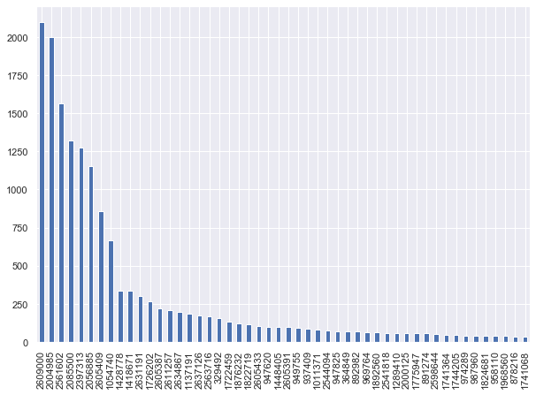

```python
activities['teacher_id'].value_counts().nlargest(50).plot(kind='bar')
```

**Findings:** Teachers 2609000, 2004985 & 2561602 are the top activity inducing teachers.  
We can check school of these teachers while exploring teachers table.

```python
len(activities['group_id'].unique())
```

```
362
```

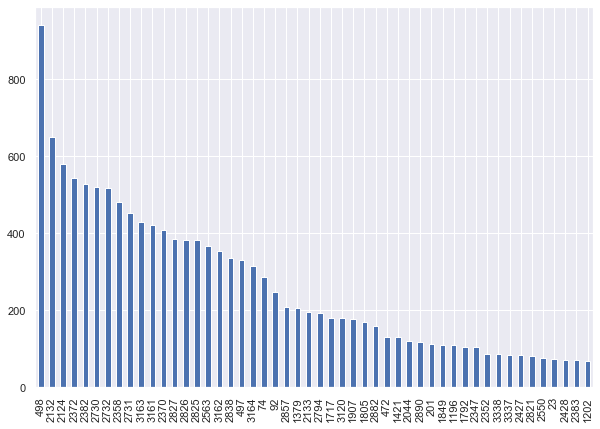

```python
activities['group_id'].value_counts().nlargest(50).plot(kind='bar')
```

```python
#Creating a variable - Day of week - from date of activity
activities['date'] = pd.to_datetime(activities['date'])
activities['day_of_week'] = activities['date'].dt.weekday_name
```

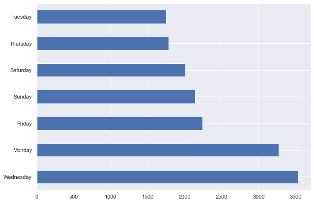

```python
activities['day_of_week'].value_counts().plot(kind='barh')
```

**Finding:** The most amount of activity is observed on Monday and Wednesday.  
We can further deep dive into what activities are most common on these 2 days

Before we deep dive, we should check the days when a session was conducted

```python
activities[['date','day_of_week']].drop_duplicates().groupby('day_of_week')['date'].count().reset_index()
```

|  | day_of_week | date |
| --- | --- | --- |
| 0 | Friday | 6 |
| 1 | Monday | 6 |
| 2 | Saturday | 6 |
| 3 | Sunday | 7 |
| 4 | Thursday | 6 |
| 5 | Tuesday | 6 |
| 6 | Wednesday | 6 |

The number of days_of_week are almost uniform across the tenure of sessions. Hence the difference in number of activities cannot be attributed to days when session was conducted.

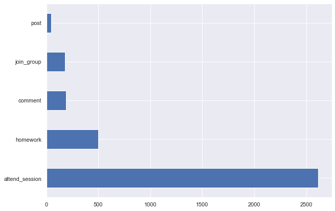

```python
activities.loc[activities['day_of_week']=='Wednesday', 'activity_type'].value_counts().plot(kind='barh')
```

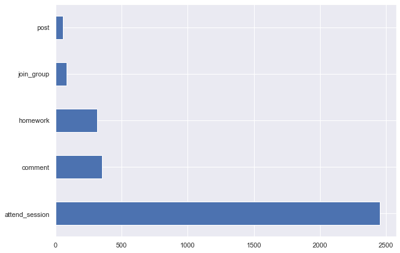

```python
activities.loc[activities['day_of_week']=='Monday', 'activity_type'].value_counts().plot(kind='barh')
```

**Findings:** Homework is submitted more often on Wednesday than other days. We can hypothesize that Wednesday is the homework submission day.  
Join group activity is also more frequent on Wednesday.  
There are more comments on Monday.

- Students table

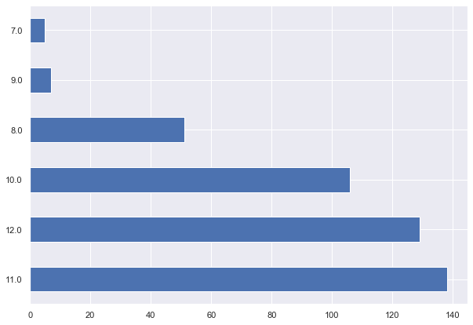

```python
students['grade'].value_counts().plot(kind='barh')
```

**Findings:** Most students are from Grade 10, 11, 12. Grade 7 and 9 students attribute very less to the population.

```python
#Creating columns for month and year of signing up
students['month_yr_signup'] = pd.to_datetime(students['signup_date']).dt.to_period('M')
students['month_signup'] = pd.DatetimeIndex(students['signup_date']).month
students['year_signup'] = pd.DatetimeIndex(students['signup_date']).year
```

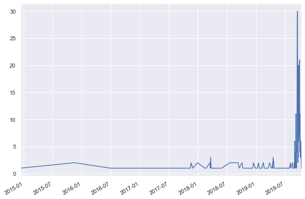

```python
students['signup_date'].value_counts().plot()
```

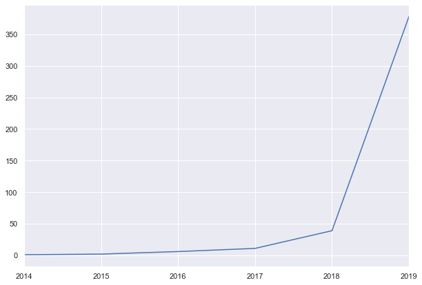

```python
students['year_signup'].value_counts().plot()
```

**Findings:** Majority of students joined in 2019. Sum of all students who joined in other years is less than those who joined in 2019

```python
school_dist = students.groupby('school_id')['students'].count().reset_index()

school_dist['Percentage'] = 100 * school_dist['students']  / school_dist['students'].sum()

print(school_dist.sort_values(by='Percentage', ascending=False))
```

```
    school_id  students  Percentage
11      19231       145   33.180778
16      41980        75   17.162471
2       10178        53   12.128146
5       13920        51   11.670481
10      18699        45   10.297483
0         374        35    8.009153
17      53264         3    0.686499
15      21339         3    0.686499
7       15702         3    0.686499
14      21308         3    0.686499
1        1769         3    0.686499
12      19384         2    0.457666
13      19622         2    0.457666
9       17864         1    0.228833
8       17028         1    0.228833
6       15701         1    0.228833
4       12517         1    0.228833
3       10463         1    0.228833
18      90642         1    0.228833
19      91119         1    0.228833
20      93951         1    0.228833
21      94448         1    0.228833
22      94710         1    0.228833
23      94911         1    0.228833
24      95773         1    0.228833
25      95814         1    0.228833
26      96784         1    0.228833
```

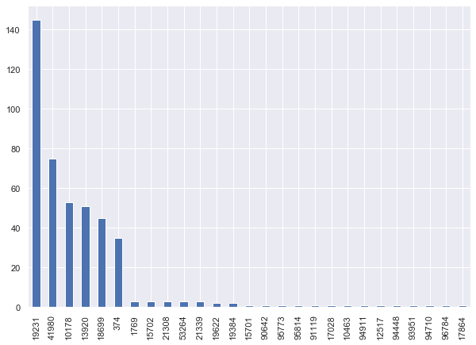

```python
students['school_id'].value_counts().plot(kind = 'bar')
```

**Finding:** School 19231 & 41980 consist of >50% of all student population.

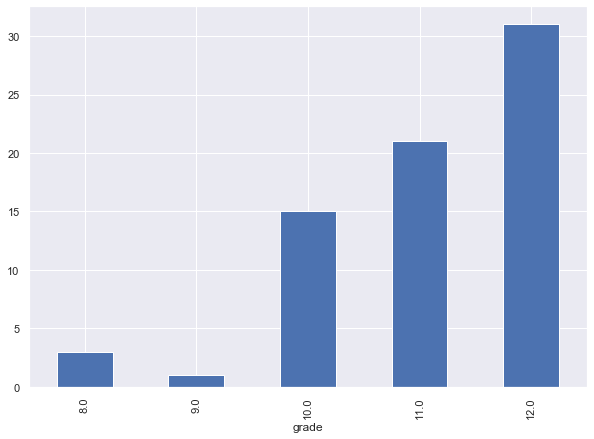

```python
activities.loc[activities['group_id'] == 498].merge(students, on = 'students', how = 'left')[['group_id','grade',
          'students']].drop_duplicates().groupby(['grade']).size().plot(kind='bar')
```

**Findings:** Students from the most active group are mostly from grade 12. This graph is similar to overall students distribution across grades, hence does not add much value.

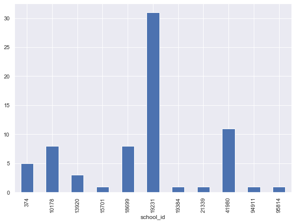

```python
activities.loc[activities['group_id'] == 498].merge(students, on = 'students', how = 'left')[['group_id','school_id',
          'students']].drop_duplicates().groupby(['school_id']).size().plot(kind='bar')
```

**Findings:** Most active groups' members are mostly from school 19231. This graph is also similar to overall students' distribution across schools. Hence, does not add much value.

- Teachers table

```python
#Checking school of highest activity inducing teachers : 2609000, 2004985 & 2561602 (discussed above)
teachers.loc[teachers['teacher_id'].isin(['2609000', '2004985', '2561602'])]
```

|  | teacher_id | school_id |
| --- | --- | --- |
| 74 | 2004985 | 18554 |
| 89 | 2609000 | 19231 |
| 172 | 2561602 | 19231 |

**Findings:** The top 3 activity inducing teachers are from school 19231 and 18554

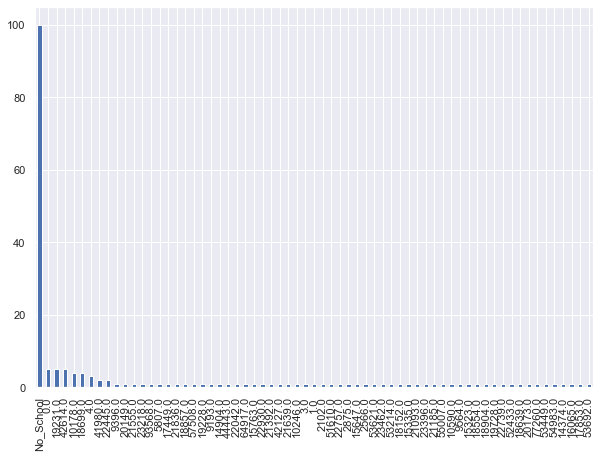

```python
teachers['school_id'].value_counts().plot(kind='bar')
```

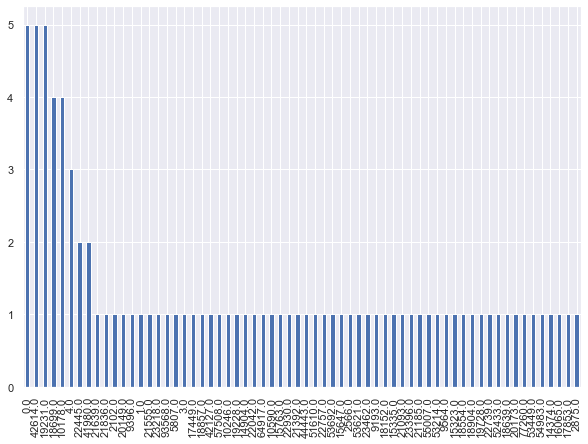

```python
teachers[teachers['school_id']!='No_School']['school_id'].value_counts().plot(kind='bar')
```

- Bivariate Analysis

> *Teacher vs Day of Week*

Assuming that each teacher can conduct one session in a day in a group, we can calculate which teacher attends most sessions on which day

```python
#Getting frequency of sessions for a teacher
teachers_day_base = activities[['teacher_id','group_id','date','day_of_week']].drop_duplicates().groupby(['teacher_id',
               'day_of_week']).size().reset_index(name = 'Freq')
print(teachers_day_base.head())

#transforming
teachers_day = teachers_day_base.pivot_table('Freq','teacher_id','day_of_week').reset_index()
teachers_day.fillna(0, inplace = True)
teachers_day.head()
```

```
   teacher_id day_of_week  Freq
0      240904    Saturday     2
1      329492      Friday     1
2      329492      Monday     2
3      329492    Saturday     1
4      329492      Sunday     2
```

| day_of_week | teacher_id | Friday | Monday | Saturday | Sunday | Thursday | Tuesday | Wednesday |
| --- | --- | --- | --- | --- | --- | --- | --- | --- |
| 0 | 240904 | 0.0 | 0.0 | 2.0 | 0.0 | 0.0 | 0.0 | 0.0 |
| 1 | 329492 | 1.0 | 2.0 | 1.0 | 2.0 | 3.0 | 1.0 | 3.0 |
| 2 | 364849 | 5.0 | 6.0 | 4.0 | 4.0 | 4.0 | 6.0 | 4.0 |
| 3 | 436016 | 3.0 | 0.0 | 0.0 | 0.0 | 0.0 | 1.0 | 3.0 |
| 4 | 874667 | 0.0 | 0.0 | 2.0 | 5.0 | 1.0 | 5.0 | 0.0 |

Since there are a number of teachers, we won't check days for all of them. However, we can check the days for top 3 activity inducing teachers: 2609000, 2004985, 2561602

```python
teachers_day.loc[teachers_day['teacher_id'].isin(['2609000', '2004985', '2561602'])]
```

| day_of_week | teacher_id | Friday | Monday | Saturday | Sunday | Thursday | Tuesday | Wednesday |
| --- | --- | --- | --- | --- | --- | --- | --- | --- |
| 145 | 2004985 | 4.0 | 5.0 | 1.0 | 9.0 | 2.0 | 5.0 | 4.0 |
| 158 | 2561602 | 3.0 | 3.0 | 3.0 | 9.0 | 3.0 | 6.0 | 6.0 |
| 176 | 2609000 | 12.0 | 14.0 | 16.0 | 16.0 | 11.0 | 12.0 | 21.0 |

**Findings:** Teacher 2609000 had the most sessions on Wednesdays and teachers 2562602 & 2004985 had most sessions on Sunday.

> *Grade vs activity*

```python
#Transforming activities table to get activity info at student level
act_trans_base = activities[['students','activity_type']].groupby(['students', 'activity_type']).size().reset_index(
    name="Freq")
act_trans_base.head()
```

|  | students | activity_type | Freq |
| --- | --- | --- | --- |
| 0 | 114565 | attend_session | 45 |
| 1 | 114565 | homework | 15 |
| 2 | 329492 | post | 18 |
| 3 | 478295 | attend_session | 95 |
| 4 | 478295 | homework | 3 |

```python
act_trans = act_trans_base.pivot_table('Freq', 'students', 'activity_type').reset_index()
act_trans.fillna(0, inplace = True)
print(len(act_trans))
act_trans.head()
```

```
432
```

| activity_type | students | attend_session | comment | homework | join_group | post |
| --- | --- | --- | --- | --- | --- | --- |
| 0 | 114565 | 45.0 | 0.0 | 15.0 | 0.0 | 0.0 |
| 1 | 329492 | 0.0 | 0.0 | 0.0 | 0.0 | 18.0 |
| 2 | 478295 | 95.0 | 0.0 | 3.0 | 2.0 | 1.0 |
| 3 | 493803 | 9.0 | 0.0 | 0.0 | 0.0 | 0.0 |
| 4 | 560168 | 69.0 | 0.0 | 6.0 | 0.0 | 0.0 |

```python
act_trans_stu = act_trans.merge(students, on = 'students', how = 'inner')
act_trans_stu
```

|  | students | attend_session | comment | homework | join_group | post | school_id | grade | signup_date | month_yr_signup | month_signup | year_signup |
| --- | --- | --- | --- | --- | --- | --- | --- | --- | --- | --- | --- | --- |
| 0 | 114565 | 45.0 | 0.0 | 15.0 | 0.0 | 0.0 | 19231 | 11.0 | 2014-12-12 | 2014-12 | 12 | 2014 |
| 1 | 329492 | 0.0 | 0.0 | 0.0 | 0.0 | 18.0 | 41980 | 12.0 | 2015-11-16 | 2015-11 | 11 | 2015 |
| 2 | 478295 | 95.0 | 0.0 | 3.0 | 2.0 | 1.0 | 19231 | 12.0 | 2016-06-30 | 2016-06 | 6 | 2016 |
| 3 | 493803 | 9.0 | 0.0 | 0.0 | 0.0 | 0.0 | 41980 | 12.0 | 2016-08-21 | 2016-08 | 8 | 2016 |
| 4 | 560168 | 69.0 | 0.0 | 6.0 | 0.0 | 0.0 | 19231 | 10.0 | 2016-10-23 | 2016-10 | 10 | 2016 |
| ... | ... | ... | ... | ... | ... | ... | ... | ... | ... | ... | ... | ... |
| 427 | 2768691 | 3.0 | 0.0 | 0.0 | 11.0 | 0.0 | 53264 | 12.0 | 2019-10-10 | 2019-10 | 10 | 2019 |
| 428 | 2769963 | 0.0 | 0.0 | 2.0 | 0.0 | 0.0 | 18699 | 12.0 | 2019-10-10 | 2019-10 | 10 | 2019 |
| 429 | 2770207 | 0.0 | 0.0 | 2.0 | 0.0 | 0.0 | 18699 | 12.0 | 2019-10-10 | 2019-10 | 10 | 2019 |
| 430 | 2770252 | 0.0 | 0.0 | 2.0 | 0.0 | 0.0 | 18699 | 12.0 | 2019-10-10 | 2019-10 | 10 | 2019 |
| 431 | 2783012 | 0.0 | 0.0 | 0.0 | 1.0 | 0.0 | 10178 | 12.0 | 2019-10-13 | 2019-10 | 10 | 2019 |

432 rows × 12 columns

```python
#Grouping data on grade to get aggregate activities
grade_activity = act_trans_stu.groupby(['grade'])['attend_session','comment','homework','join_group','post'].agg(sum).reset_index()
```

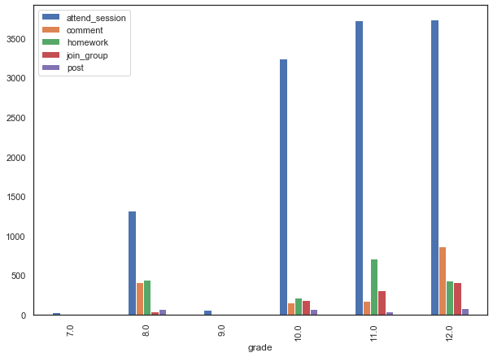

```python
grade_activity.plot(x='grade', y=['attend_session','comment','homework','join_group','post'], kind="bar")
```

**Findings:**

1. Students from grade 8 do more homework and comment when compared to attending sessions (as compared to population)
2. Students from grade 10 attend a lot of sessions but perform other activities less.
3. Students of grade 11 do the most amounts of homework
4. Students from grade 12 comment the most

> *School vs activity*

```python
#Grouping data on grade to get aggregate activities
school_activity = act_trans_stu.groupby(['school_id'])['attend_session','comment','homework','join_group','post'].agg(sum).reset_index()
```

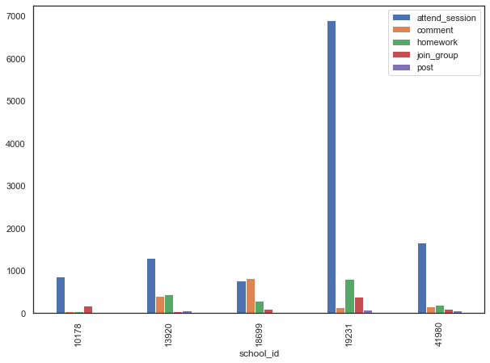

```python
#Checking only for top 5 schools: 19231, 41980, 10178, 13920, 18699
school_activity.loc[school_activity['school_id'].isin(['19231', '41980', '10178', '13920', '18699'])].plot(x='school_id',
              y=['attend_session','comment','homework','join_group','post'], kind="bar")
```

**Findings:**

1. Students from school 19231 attend more session compared to other activities with respect to other schools
2. Students from school 18699 comment more than they attend sessions. This is an unsual trend and needs to be looked into.
3. Students of school 19231 do much more homework than they comment. This is different from population where both activities are of almost equal number.
4. Students from school 10178 join groups a lot but don't do as much homework or post or comment.

*Other EDA's which can be done:*

1. Do different teachers induce different kind of activities?
2. Is there a relation between activity on a day of week and school_id?
3. Is there a relation between activity on a day of week and grade?
4. Determine which teacher teaches which grades.

### 3. Problem 1: Cohort Analysis

*Create a cohorts analyses for the students based on thier behavioral activities*

For performing cohort analysis, we first need to transform our dataset, activities table, to students-activity_date level

```python
cohort_base = activities[['students','activity_type','date']].groupby(['students', 'activity_type','date']).size().reset_index(
    name="Freq")
cohort_base.head()
```

|  | students | activity_type | date | Freq |
| --- | --- | --- | --- | --- |
| 0 | 114565 | attend_session | 2019-09-21 | 5 |
| 1 | 114565 | attend_session | 2019-09-26 | 5 |
| 2 | 114565 | attend_session | 2019-09-28 | 9 |
| 3 | 114565 | attend_session | 2019-09-30 | 15 |
| 4 | 114565 | attend_session | 2019-10-03 | 9 |

```python
cohort_base2 = cohort_base.pivot_table('Freq',['students','date'],'activity_type').fillna(0).reset_index()
cohort_base2.head()
```

| activity_type | students | date | attend_session | comment | homework | join_group | post |
| --- | --- | --- | --- | --- | --- | --- | --- |
| 0 | 114565 | 2019-09-21 | 5.0 | 0.0 | 0.0 | 0.0 | 0.0 |
| 1 | 114565 | 2019-09-25 | 0.0 | 0.0 | 2.0 | 0.0 | 0.0 |
| 2 | 114565 | 2019-09-26 | 5.0 | 0.0 | 2.0 | 0.0 | 0.0 |
| 3 | 114565 | 2019-09-28 | 9.0 | 0.0 | 0.0 | 0.0 | 0.0 |
| 4 | 114565 | 2019-09-29 | 0.0 | 0.0 | 2.0 | 0.0 | 0.0 |

```python
#For simplicity, we will club together attend_session and homework as basic_activity
#and comment, post and join_group and engagement_activity
cohort_base2['basic_activity'] = cohort_base2['attend_session'] + cohort_base2['homework']
cohort_base2['engagement_activity'] = cohort_base2['post'] + cohort_base2['comment'] + cohort_base2['join_group']
cohort_base2.drop(columns = ['attend_session','post','homework','comment','join_group'], inplace = True)
cohort_base2.head()
```

| activity_type | students | date | basic_activity | engagement_activity |
| --- | --- | --- | --- | --- |
| 0 | 114565 | 2019-09-21 | 5.0 | 0.0 |
| 1 | 114565 | 2019-09-25 | 2.0 | 0.0 |
| 2 | 114565 | 2019-09-26 | 7.0 | 0.0 |
| 3 | 114565 | 2019-09-28 | 9.0 | 0.0 |
| 4 | 114565 | 2019-09-29 | 2.0 | 0.0 |

```python
#Adding difference between 01-Sep (base date) and activity date in terms of number of weeks
cohort_base2['week_from_date'] = np.floor((cohort_base2['date'] - pd.to_datetime('2019-09-01'))/np.timedelta64(7,'D'))
cohort_base2.head()
```

| activity_type | students | date | basic_activity | engagement_activity | week_from_date |
| --- | --- | --- | --- | --- | --- |
| 0 | 114565 | 2019-09-21 | 5.0 | 0.0 | 2.0 |
| 1 | 114565 | 2019-09-25 | 2.0 | 0.0 | 3.0 |
| 2 | 114565 | 2019-09-26 | 7.0 | 0.0 | 3.0 |
| 3 | 114565 | 2019-09-28 | 9.0 | 0.0 | 3.0 |
| 4 | 114565 | 2019-09-29 | 2.0 | 0.0 | 4.0 |

```python
#Adding cohort group as the first activity week of the student

temp = pd.DataFrame(cohort_base2.groupby(['students'])['date'].min().apply(lambda x: np.floor((x - pd.to_datetime('2019-09-01'))/np.timedelta64(7,'D'))))
temp.rename(columns = {'date':'cohort_week'}, inplace = True)
cohort_base3 = cohort_base2.merge(temp, left_on = 'students', right_index = True, how = 'left')
```

```python
#Grouping data on cohort_week and week_from_date (activity week)
grouped = cohort_base3.groupby(['cohort_week', 'week_from_date'])

#Count the unique students, sum of basic_activity, and sum of engagement_activity per cohort_week + activity week
cohorts = grouped.agg({'students': pd.Series.nunique,
                       'basic_activity': np.sum,
                       'engagement_activity': np.sum})

#Changing column name
cohorts.rename(columns={'students': 'total_students'}, inplace=True)
cohorts.head()
```

| cohort_week | week_from_date | total_students | basic_activity | engagement_activity |
| --- | --- | --- | --- | --- |
| 0.0 | 0.0 | 22 | 41.0 | 179.0 |
|  | 1.0 | 8 | 147.0 | 95.0 |
|  | 2.0 | 8 | 105.0 | 115.0 |
|  | 3.0 | 12 | 155.0 | 207.0 |
|  | 4.0 | 12 | 152.0 | 58.0 |

```python
def cohort_period(df):
    """
    Creates a `cohort_period` column, which is the Nth week based on the students's first activity.
    """
    df['cohort_period'] = np.arange(len(df)) + 1
    return df

cohorts = cohorts.groupby(level=0).apply(cohort_period)
cohorts
```

| cohort_week | week_from_date | total_students | basic_activity | engagement_activity | cohort_period |
| --- | --- | --- | --- | --- | --- |
| 0.0 | 0.0 | 22 | 41.0 | 179.0 | 1 |
|  | 1.0 | 8 | 147.0 | 95.0 | 2 |
|  | 2.0 | 8 | 105.0 | 115.0 | 3 |
|  | 3.0 | 12 | 155.0 | 207.0 | 4 |
|  | 4.0 | 12 | 152.0 | 58.0 | 5 |
|  | 5.0 | 11 | 166.0 | 233.0 | 6 |
|  | 6.0 | 1 | 1.0 | 25.0 | 7 |
| 1.0 | 1.0 | 25 | 116.0 | 25.0 | 1 |
|  | 2.0 | 13 | 64.0 | 9.0 | 2 |
|  | 3.0 | 11 | 44.0 | 6.0 | 3 |
|  | 4.0 | 15 | 257.0 | 15.0 | 4 |
|  | 5.0 | 12 | 171.0 | 20.0 | 5 |
|  | 6.0 | 1 | 0.0 | 1.0 | 6 |
| 2.0 | 2.0 | 105 | 612.0 | 115.0 | 1 |
|  | 3.0 | 72 | 1014.0 | 127.0 | 2 |
|  | 4.0 | 82 | 1771.0 | 184.0 | 3 |
|  | 5.0 | 60 | 672.0 | 116.0 | 4 |
|  | 6.0 | 4 | 1.0 | 3.0 | 5 |
| 3.0 | 3.0 | 115 | 1166.0 | 160.0 | 1 |
|  | 4.0 | 95 | 2338.0 | 199.0 | 2 |
|  | 5.0 | 67 | 1443.0 | 77.0 | 3 |
|  | 6.0 | 8 | 8.0 | 8.0 | 4 |
| 4.0 | 4.0 | 110 | 821.0 | 239.0 | 1 |
|  | 5.0 | 64 | 1534.0 | 286.0 | 2 |
|  | 6.0 | 8 | 5.0 | 27.0 | 3 |
| 5.0 | 5.0 | 53 | 1110.0 | 246.0 | 1 |
|  | 6.0 | 6 | 0.0 | 14.0 | 2 |
| 6.0 | 6.0 | 2 | 0.0 | 4.0 | 1 |

We have now successfully created cohorts based on students first activity.

### 4. Problem 2: Retention Analysis

*Based on the cohorts you’ve defined, run a retention analysis for each cohort, then evaluate whether there are common characteristics that exists between high performing cohorts*

**Based on number of active students in each cohort**

We want to look at the percentage change of each cohort_week over time -- not the absolute change.  
To do this, we'll first need to create a pandas Series containing each cohort_week and its initial size, i.e. size of cohort_period 1 for every cohort_week

```python
#Changing index to cohort_week and cohort_period
cohorts.reset_index(inplace=True)
cohorts.set_index(['cohort_week', 'cohort_period'], inplace=True)

#Create a Series holding the total size of each CohortGroup
cohort_group_size = cohorts['total_students'].groupby(level=0).first()
cohort_group_size.head()
```

```
cohort_week
0.0     22
1.0     25
2.0    105
3.0    115
4.0    110
Name: total_students, dtype: int64
```

```python
#Unstacking the cohorts dataset on total_students. This would give us a dataset with cohort_group in columns and cohort_week
#in rows. Then divide the number of active students in all cohort period by the initial number of students
#in that cohort_week (cohort_group_size)
student_retention = cohorts['total_students'].unstack(0).divide(cohort_group_size, axis=1)
student_retention
```

| cohort_week cohort_period | 0.0 | 1.0 | 2.0 | 3.0 | 4.0 | 5.0 | 6.0 |
| --- | --- | --- | --- | --- | --- | --- | --- |
| 1 | 1.000000 | 1.00 | 1.000000 | 1.000000 | 1.000000 | 1.000000 | 1.0 |
| 2 | 0.363636 | 0.52 | 0.685714 | 0.826087 | 0.581818 | 0.113208 | NaN |
| 3 | 0.363636 | 0.44 | 0.780952 | 0.582609 | 0.072727 | NaN | NaN |
| 4 | 0.545455 | 0.60 | 0.571429 | 0.069565 | NaN | NaN | NaN |
| 5 | 0.545455 | 0.48 | 0.038095 | NaN | NaN | NaN | NaN |
| 6 | 0.500000 | 0.04 | NaN | NaN | NaN | NaN | NaN |
| 7 | 0.045455 | NaN | NaN | NaN | NaN | NaN | NaN |

```python
cohort_group_size
```

```
cohort_week
0.0     22
1.0     25
2.0    105
3.0    115
4.0    110
5.0     53
6.0      2
Name: total_students, dtype: int64
```

```
(1, 8)
```

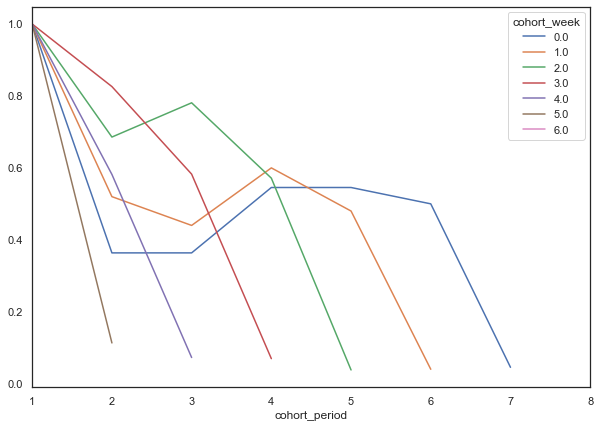

```python
#Visualizing change in total_students over cohort_period for all cohorts
student_retention.plot()
plt.xlim(1,8)
```

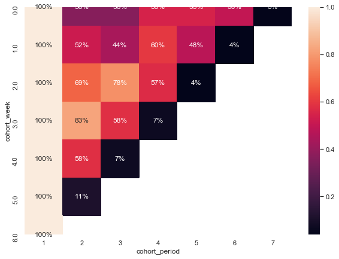

```python
#Visualizing in form of a heatmap
sns.set(style='white')
sns.heatmap(student_retention.T, mask=student_retention.T.isnull(), annot=True, fmt='.0%');
```

**Findings:**

1. Cohort 3 has performed the best in second week but dropped a lot in following weeks
2. Cohort 5 has the worst drop from week 1 to 2
3. Cohort 0 & 1 see a rise in students in week 4, Cohort 2 sees a rise in week 3. Looking at the trend, it can be said that there is a possiblity for other cohorts to revive over time and show positive growth.
4. Almost all cohorts fall to ~10% students in their last week
- **High perfroming Cohorts** : Cohort 0, 1 & 2

**Based on activity of students in each cohort**

```python
#Normalizing activity with respect to number of students active
cohorts['norm_basic_activity'] = cohorts['basic_activity']/cohorts['total_students']
cohorts['norm_engage_activity'] = cohorts['engagement_activity']/cohorts['total_students']

#Creating copy
cohorts2 = copy.deepcopy(cohorts)

#Removing base activity columns
del cohorts2['basic_activity']
del cohorts2['engagement_activity']

#Create a Series holding the total size of each CohortGroup
cohort_group_size_basic = cohorts2['norm_basic_activity'].groupby(level=0).first()
print(cohort_group_size_basic.head())
cohort_group_size_engage = cohorts2['norm_engage_activity'].groupby(level=0).first()
print(cohort_group_size_engage.head())
```

```
cohort_week
0.0     1.863636
1.0     4.640000
2.0     5.828571
3.0    10.139130
4.0     7.463636
Name: norm_basic_activity, dtype: float64
cohort_week
0.0    8.136364
1.0    1.000000
2.0    1.095238
3.0    1.391304
4.0    2.172727
Name: norm_engage_activity, dtype: float64
```

```python
#Unstacking the cohorts dataset on basic and engagement activity. This would give us a dataset with cohort_group
#in columns and cohort_week in rows. Then divide the number of activity in all cohort period by the initial
#activity in that cohort_week (cohort_group_size)
basic_act_retention = cohorts2['norm_basic_activity'].unstack(0).divide(cohort_group_size_basic, axis=1)
print(basic_act_retention)
engage_act_retention = cohorts2['norm_engage_activity'].unstack(0).divide(cohort_group_size_engage, axis=1)
print(engage_act_retention)
```

```
cohort_week         0.0       1.0       2.0       3.0       4.0  5.0  6.0
cohort_period
1              1.000000  1.000000  1.000000  1.000000  1.000000  1.0  NaN
2              9.859756  1.061008  2.416258  2.427282  3.211404  0.0  NaN
3              7.042683  0.862069  3.705464  2.124178  0.083739  NaN  NaN
4              6.930894  3.692529  1.921569  0.098628       NaN  NaN  NaN
5              6.796748  3.071121  0.042892       NaN       NaN  NaN  NaN
6              8.097561  0.000000       NaN       NaN       NaN  NaN  NaN
7              0.536585       NaN       NaN       NaN       NaN  NaN  NaN
cohort_week         0.0       1.0       2.0       3.0       4.0      5.0  6.0
cohort_period
1              1.000000  1.000000  1.000000  1.000000  1.000000  1.00000  1.0
2              1.459497  0.692308  1.610507  1.505592  2.056747  0.50271  NaN
3              1.766760  0.545455  2.048780  0.826026  1.553347      NaN  NaN
4              2.120112  1.000000  1.765217  0.718750       NaN      NaN  NaN
5              0.594041  1.666667  0.684783       NaN       NaN      NaN  NaN
6              2.603352  1.000000       NaN       NaN       NaN      NaN  NaN
7              3.072626       NaN       NaN       NaN       NaN      NaN  NaN
```

```
(1, 8)
```

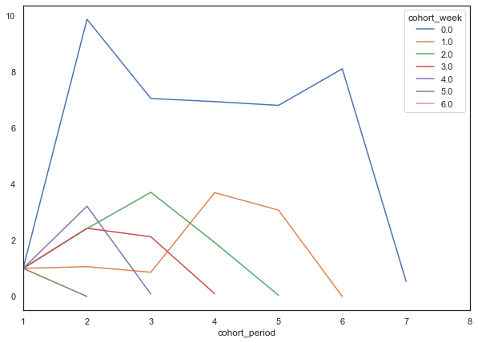

```python
#Visualizing change in basic_act over cohort_period for all cohorts
basic_act_retention.plot()
plt.xlim(1,8)
```

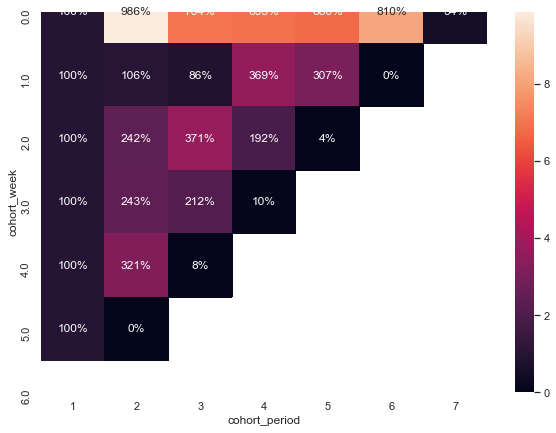

```python
#Visualizing in form of a heatmap
sns.set(style='white')
sns.heatmap(basic_act_retention.T, mask=basic_act_retention.T.isnull(), annot=True, fmt='.0%');
```

```
(1, 8)
```

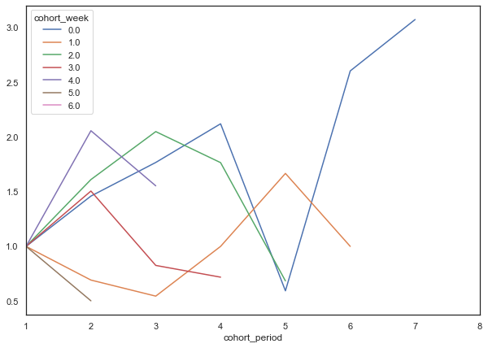

```python
#Visualizing change in engage_act over cohort_period for all cohorts
engage_act_retention.plot()
plt.xlim(1,8)
```

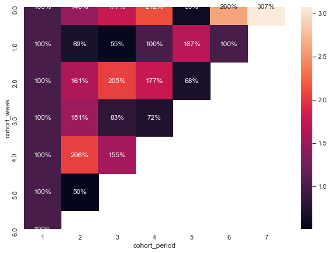

```python
#Visualizing in form of a heatmap
sns.set(style='white')
sns.heatmap(engage_act_retention.T, mask=engage_act_retention.T.isnull(), annot=True, fmt='.0%');
```

**Findings:**

**Deep Dive into high performing cohorts: 0 & 2**

```python
#Getting details of students in cohort 0 & 2
high_cohorts = temp.loc[temp['cohort_week'].isin(['0','2'])].reset_index().merge(students, on = 'students', how = 'inner')
```

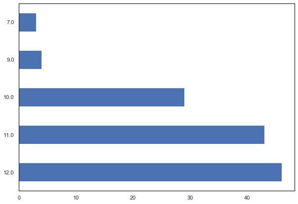

```python
high_cohorts['grade'].value_counts().plot(kind='barh')
```

**Findings:** Although, population had a significant number of students from grade 8, high performing cohorts don't have any student from grade 8.

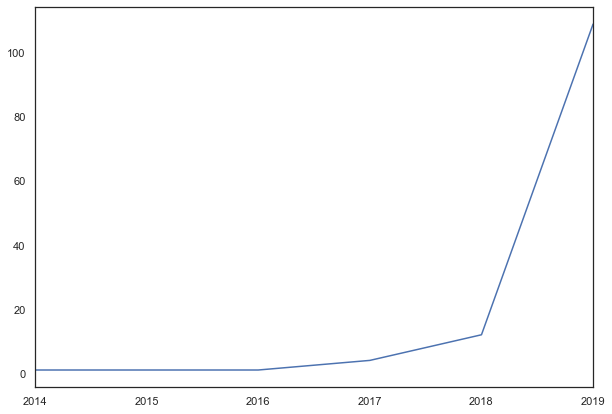

```python
high_cohorts['year_signup'].value_counts().plot()
```

**Findings:** Signup dates distribution is similar to population

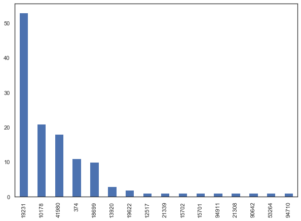

```python
high_cohorts['school_id'].value_counts().plot(kind = 'bar')
```

**Findings:** Top 5 schools in number of students were 19281, 41980, 10178, 13920 and 18699. (from last EDA)  
Top 5 schools for highly active cohort students are 19231, 10178, 41980, **374** and 18699. Although number of students are less from school 374, they are more active.

### 5. Clustering Analysis

*Performing cluserting analysis based on students' activities to find underlying patterns within their activity frequency and group them into meaningful clusters.*

```python
#Transforming activities table to get activity info at student level
act_cohort_base = activities[['students','activity_type']].groupby(['students', 'activity_type']).size().reset_index(
    name="Freq")
act_cohort_base.head()
```

|  | students | activity_type | Freq |
| --- | --- | --- | --- |
| 0 | 114565 | attend_session | 45 |
| 1 | 114565 | homework | 15 |
| 2 | 329492 | post | 18 |
| 3 | 478295 | attend_session | 95 |
| 4 | 478295 | homework | 3 |

```python
act_cohort = act_cohort_base.pivot_table('Freq', 'students', 'activity_type')
act_cohort.fillna(0, inplace = True)
print(len(act_cohort))
act_cohort.head()
```

```
432
```

| activity_type students | attend_session | comment | homework | join_group | post |
| --- | --- | --- | --- | --- | --- |
| 114565 | 45.0 | 0.0 | 15.0 | 0.0 | 0.0 |
| 329492 | 0.0 | 0.0 | 0.0 | 0.0 | 18.0 |
| 478295 | 95.0 | 0.0 | 3.0 | 2.0 | 1.0 |
| 493803 | 9.0 | 0.0 | 0.0 | 0.0 | 0.0 |
| 560168 | 69.0 | 0.0 | 6.0 | 0.0 | 0.0 |

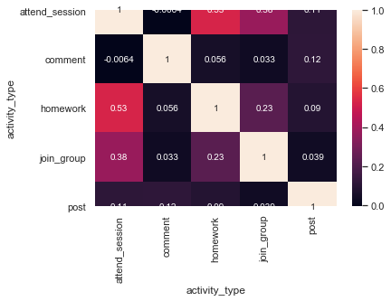

```python
#Finding correlation between activity types
corrMatrix = act_cohort.corr()
sns.heatmap(corrMatrix, annot=True)
```

There is a mild correlation between homework and attend_session. We don't need to remove any of them.

```python
#Adding signup date of students into the dataset to get the number of days student has been active.
#Will be used later for normalizing
act_cohort_new = act_cohort.merge(students[['signup_date','students']], left_index= True, right_on='students')
act_cohort_new = act_cohort_new.set_index('students')
```

```python
#Adding last active date (last date of activity) to get days since student is in the system
act_cohort_new['last_date'] = pd.to_datetime('2019-10-13')
act_cohort_new['days'] = (act_cohort_new['last_date'] - act_cohort_new['signup_date'])/np.timedelta64(1,'D')
```

```python
act_cohort_new[act_cohort_new['days']<3]
```

| students | attend_session | comment | homework | join_group | post | signup_date | last_date | days |
| --- | --- | --- | --- | --- | --- | --- | --- | --- |
| 2783012 | 0.0 | 0.0 | 0.0 | 1.0 | 0.0 | 2019-10-13 | 2019-10-13 | 0.0 |

There is only one student with number of days into system less than 3 days (that too 0 day). So we will treat this student as a separate case and perform clustering analysis on the rest of the students.

```python
act_cohort_new = act_cohort_new.loc[act_cohort_new['days']!=0,]
```

```python
#Signup date is from 2014 onwards but usage is from 1-Sep-19 onwards.
#So wherever days is greater than 42 (1-Sep - 13-Oct), we'll cap it to 42 days
act_cohort_new.loc[act_cohort_new['days']>42,'days'] = 42
max(act_cohort_new['days'])
```

```
42.0
```

```python
#Normalizing the usage with the number of days the student has been active
for x in range(0,5):
    act_cohort_new.iloc[:,x] = act_cohort_new.iloc[:,x]/act_cohort_new.iloc[:,7]
```

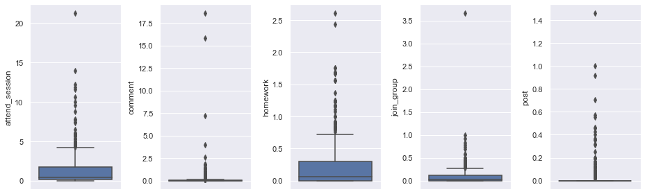

```python
#Finding outliers using box plot
plt.figure(figsize=(13, 4))
for k in range(1,6):
    plt.subplot(1,5,k)
    sns.boxplot(y = act_cohort_new.iloc[:,k-1])
plt.tight_layout()
plt.show()
```

Looking at box plot, we can identify that there are a number of entries which are out of expected range. But all won't cause much problem.  
However, There is few entries which are signifact outliers and needs to be treated.  
We will cap max value of:  
Attend session to 14  
Comment to 3  
Join group to 1  
Post to 0.9

```python
act_cohort_new.loc[act_cohort_new['comment']>3,'comment'] = 3
act_cohort_new.loc[act_cohort_new['attend_session']>14,'attend_session'] = 14
act_cohort_new.loc[act_cohort_new['join_group']>1,'join_group'] = 1
act_cohort_new.loc[act_cohort_new['post']>0.9,'post'] = 0.9
```

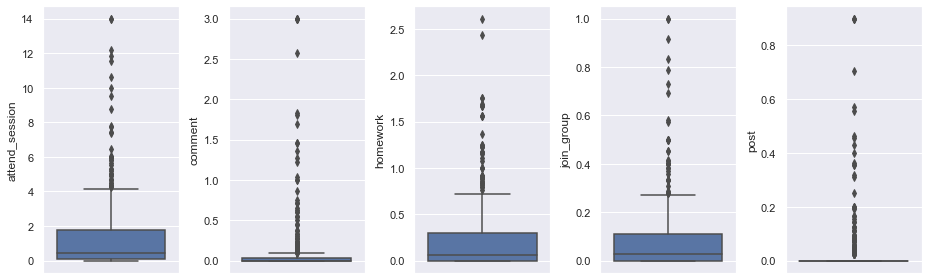

```python
#Checking distribution after treating outliers
plt.figure(figsize=(13, 4))
for k in range(1,6):
    plt.subplot(1,5,k)
    sns.boxplot(y = act_cohort_new.iloc[:,k-1])
plt.tight_layout()
plt.show()
```

```python
#Getting the final dataset by removing date columns
act_cohort_final = act_cohort_new.iloc[:,0:5]
act_cohort_final
```

| students | attend_session | comment | homework | join_group | post |
| --- | --- | --- | --- | --- | --- |
| 114565 | 1.071429 | 0.0 | 0.357143 | 0.000000 | 0.000000 |
| 329492 | 0.000000 | 0.0 | 0.000000 | 0.000000 | 0.428571 |
| 478295 | 2.261905 | 0.0 | 0.071429 | 0.047619 | 0.023810 |
| 493803 | 0.214286 | 0.0 | 0.000000 | 0.000000 | 0.000000 |
| 560168 | 1.642857 | 0.0 | 0.142857 | 0.000000 | 0.000000 |
| ... | ... | ... | ... | ... | ... |
| 2767872 | 0.333333 | 1.0 | 0.000000 | 0.000000 | 0.000000 |
| 2768691 | 1.000000 | 0.0 | 0.000000 | 1.000000 | 0.000000 |
| 2769963 | 0.000000 | 0.0 | 0.666667 | 0.000000 | 0.000000 |
| 2770207 | 0.000000 | 0.0 | 0.666667 | 0.000000 | 0.000000 |
| 2770252 | 0.000000 | 0.0 | 0.666667 | 0.000000 | 0.000000 |

431 rows × 5 columns

```python
#Scaling before PCA
from sklearn.preprocessing import StandardScaler

#Standardizing the features
x = StandardScaler().fit_transform(act_cohort_final)
```

```python
#Performing principal component analysis
from sklearn.decomposition import PCA
pca = PCA(0.95)
principalComponents = pca.fit_transform(act_cohort_final)
```

```python
principalComponents
```

[output not shown]

[output cut: 376 more lines]

[output not shown]

```python
#Storing PC into a dataframe
principalDf = pd.DataFrame(data = principalComponents
            , columns = ['principal component 1', 'principal component 2'])
```

```python
#Calculating hopkins clustering tendency statistic to see if relevant clusters can be formed
from sklearn.neighbors import NearestNeighbors
from random import sample
from numpy.random import uniform
from math import isnan

def hopkins(X):
    d = X.shape[1]
    #d = len(vars) # columns
    n = len(X) # rows
    m = int(0.1 * n) # heuristic from article [1]
    nbrs = NearestNeighbors(n_neighbors=1).fit(X.values)

    rand_X = sample(range(0, n, 1), m)

    ujd = []
    wjd = []
    for j in range(0, m):
        u_dist, _ = nbrs.kneighbors(uniform(np.amin(X,axis=0),np.amax(X,axis=0),d).reshape(1, -1), 2, return_distance=True)
        ujd.append(u_dist[0][1])
        w_dist, _ = nbrs.kneighbors(X.iloc[rand_X[j]].values.reshape(1, -1), 2, return_distance=True)
        wjd.append(w_dist[0][1])

    H = sum(ujd) / (sum(ujd) + sum(wjd))
    if isnan(H):
        print(ujd, wjd)
        H = 0

    return H
```

```python
hopkins(principalDf)
```

```
0.9081905170772409
```

Dataset has great tendency to be clustered. (Values above 0.7 are good)

Finding optimal number of cluster

```python
#Importing reqd packages
from sklearn.cluster import KMeans
from sklearn import metrics
from scipy.spatial.distance import cdist
```

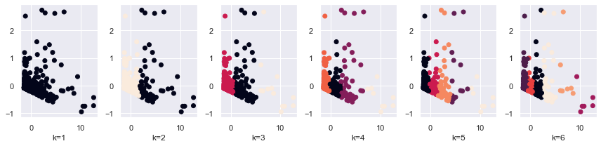

```python
#Plotting data across 2 components and 1:6 clusters to visualize how the clusters will look for different values of k
plt.figure(figsize=(12, 3))
for k in range(1,7):
    kmeans = KMeans(n_clusters=k)
    a = kmeans.fit_predict(principalDf)
    plt.subplot(1,6,k)
    plt.scatter(principalDf.iloc[:,0], principalDf.iloc[:,1], c=a)
    plt.xlabel('k='+str(k))
plt.tight_layout()
plt.show()
```

```python
#Creating inertias and distrotion values for different values of k
distortions = []
inertias = []
mapping1 = {}
mapping2 = {}
K = range(1,10)

for k in K:
#Building and fitting the model
    kmeanModel = KMeans(n_clusters=k).fit(principalDf)
    kmeanModel.fit(principalDf)

    distortions.append(sum(np.min(cdist(principalDf, kmeanModel.cluster_centers_,
    'euclidean'),axis=1)) / principalDf.shape[0])
    inertias.append(kmeanModel.inertia_)

    mapping1[k] = sum(np.min(cdist(principalDf, kmeanModel.cluster_centers_,
    'euclidean'),axis=1)) / principalDf.shape[0]
    mapping2[k] = kmeanModel.inertia_
```

```python
for key,val in mapping1.items():
    print(str(key)+' : '+str(val))
```

```
1 : 1.4886733785125454
2 : 0.8794484123597225
3 : 0.6688954107169424
4 : 0.5006117824770122
5 : 0.44311834551728363
6 : 0.3958695974494821
7 : 0.37322836187733455
8 : 0.3347542041802491
9 : 0.30886084456663104
```

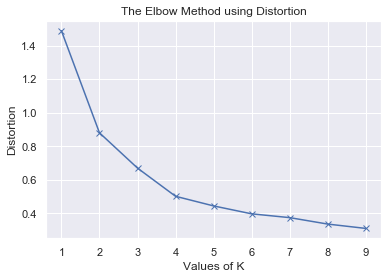

```python
plt.plot(K, distortions, 'bx-')
plt.xlabel('Values of K')
plt.ylabel('Distortion')
plt.title('The Elbow Method using Distortion')
plt.show()
```

```python
for key,val in mapping2.items():
    print(str(key)+' : '+str(val))
```

```
1 : 2068.175191190454
2 : 743.2735227190807
3 : 344.32201479910105
4 : 220.3659276239449
5 : 161.15626827290356
6 : 134.31114030299528
7 : 110.19673671812163
8 : 92.97882300397086
9 : 81.55078447146175
```

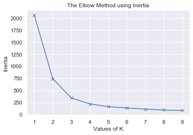

```python
plt.plot(K, inertias, 'bx-')
plt.xlabel('Values of K')
plt.ylabel('Inertia')
plt.title('The Elbow Method using Inertia')
plt.show()
```

Looking at both plot, we select 3 number of clusters to be optimal.

```python
#Performing clustering
kmeans = KMeans(n_clusters=3)
act_out = pd.DataFrame(kmeans.fit_predict(principalDf))
act_out.columns = ['Cluster']
```

```python
#Validating the cluster using Dunn index
from sklearn.metrics.pairwise import euclidean_distances

def delta(ck, cl):
    values = np.ones([len(ck), len(cl)])*10000

    for i in range(0, len(ck)):
        for j in range(0, len(cl)):
            values[i, j] = np.linalg.norm(ck[i]-cl[j])

    return np.min(values)

def big_delta(ci):
    values = np.zeros([len(ci), len(ci)])

    for i in range(0, len(ci)):
        for j in range(0, len(ci)):
            values[i, j] = np.linalg.norm(ci[i]-ci[j])

    return np.max(values)

def dunn(k_list):
    """ Dunn index [CVI]

    Parameters
    ----------
    k_list : list of np.arrays
    A list containing a numpy array for each cluster |c| = number of clusters
    c[K] is np.array([N, p]) (N : number of samples in cluster K, p : sample dimension)
    """
    deltas = np.ones([len(k_list), len(k_list)])*1000000
    big_deltas = np.zeros([len(k_list), 1])
    l_range = list(range(0, len(k_list)))

    for k in l_range:
        for l in (l_range[0:k]+l_range[k+1:]):
            deltas[k, l] = delta(k_list[k], k_list[l])

        big_deltas[k] = big_delta(k_list[k])

    di = np.min(deltas)/np.max(big_deltas)
    return di
```

```python
act_out.index = principalDf.index
prediction = pd.concat([principalDf, act_out], axis = 1)

# We store the clusters
clus0 = prediction.loc[prediction.Cluster == 0]
clus1 = prediction.loc[prediction.Cluster == 1]
clus2 = prediction.loc[prediction.Cluster == 2]
cluster_list = [clus0.values, clus1.values, clus2.values]

print(dunn(cluster_list))
```

```
0.146589973824247
```

Dunn index value of >0.05 is desired. Hence, clusters are relevant.

```python
#Joining clustering output with base dataset
act_out.index = act_cohort_final.index
act_out_df = pd.concat([act_cohort_final, act_out], axis = 1)
```

```python
from IPython.display import display
display('Cluster 0',act_out_df.loc[act_out_df['Cluster'] == 0,'attend_session':'post'].describe())
display('Cluster 1',act_out_df.loc[act_out_df['Cluster'] == 1,'attend_session':'post'].describe())
display('Cluster 2',act_out_df.loc[act_out_df['Cluster'] == 2,'attend_session':'post'].describe())
```

```
'Cluster 0'
```

|  | attend_session | comment | homework | join_group | post |
| --- | --- | --- | --- | --- | --- |
| count | 338.000000 | 338.000000 | 338.000000 | 338.000000 | 338.000000 |
| mean | 0.488189 | 0.048512 | 0.142573 | 0.072110 | 0.017873 |
| std | 0.545700 | 0.216276 | 0.280783 | 0.128158 | 0.069938 |
| min | 0.000000 | 0.000000 | 0.000000 | 0.000000 | 0.000000 |
| 25% | 0.071429 | 0.000000 | 0.000000 | 0.000000 | 0.000000 |
| 50% | 0.259006 | 0.000000 | 0.000000 | 0.023810 | 0.000000 |
| 75% | 0.774457 | 0.000000 | 0.156883 | 0.094156 | 0.000000 |
| max | 2.055556 | 3.000000 | 1.750000 | 1.000000 | 0.703704 |

```
'Cluster 1'
```

|  | attend_session | comment | homework | join_group | post |
| --- | --- | --- | --- | --- | --- |
| count | 80.000000 | 80.000000 | 80.000000 | 80.000000 | 80.000000 |
| mean | 3.661975 | 0.304145 | 0.493866 | 0.138089 | 0.080665 |
| std | 1.172888 | 0.684945 | 0.453164 | 0.196439 | 0.190039 |
| min | 2.120000 | 0.000000 | 0.000000 | 0.000000 | 0.000000 |
| 25% | 2.539091 | 0.000000 | 0.189732 | 0.000000 | 0.000000 |
| 50% | 3.508547 | 0.000000 | 0.357143 | 0.069048 | 0.000000 |
| 75% | 4.425000 | 0.161667 | 0.680000 | 0.192857 | 0.069581 |
| max | 6.473684 | 3.000000 | 2.611111 | 1.000000 | 0.900000 |

```
'Cluster 2'
```

|  | attend_session | comment | homework | join_group | post |
| --- | --- | --- | --- | --- | --- |
| count | 13.000000 | 13.000000 | 13.000000 | 13.000000 | 13.000000 |
| mean | 10.211268 | 0.503569 | 1.097670 | 0.141651 | 0.068956 |
| std | 2.371854 | 0.751697 | 0.628193 | 0.206598 | 0.163386 |
| min | 7.363636 | 0.000000 | 0.250000 | 0.000000 | 0.000000 |
| 25% | 7.769231 | 0.000000 | 0.714286 | 0.000000 | 0.000000 |
| 50% | 10.000000 | 0.083333 | 0.909091 | 0.000000 | 0.000000 |
| 75% | 11.833333 | 0.625000 | 1.555556 | 0.230769 | 0.000000 |
| max | 14.000000 | 2.571429 | 2.428571 | 0.578947 | 0.571429 |

**What next?**  
Analysis:

1. We can break down these clusters at class level, teacher level and school level to gather further insights.
2. We can look at their signup dates to see if there's trend within old students and newly joined students
3. We can check within the groups to see if activity by a few students in a group drives other students to be more active

Experimentation:

1. We can float surveys across cluster2 (active) students to get their perspective on what is working for them. Similarly for cluster0 & cluster1 (inactive & moderately active) students to get an idea of their needs
2. We can conduct pilot programs or experiments on group of Cluster0 (inactive) students trying to increase their activity